# R Notebook

```r
burn <- read.table("Burn.txt", quote = "\"", comment.char = "")

colnames(burn) = c("treatment", "gender", "burns.percentage",
    "head", "buttock", "torso", "upper.leg", "lower.leg",
    "respiratory.system", "burn.type", "time", "cens")

burn$gender = factor(burn$gender, levels = c(0, 1),
    labels = c("Man", "Woman"))
burn$treatment = factor(burn$treatment, levels = c(0,
    1), labels = c("bathing care", "body cleansing"))
burn$burn.type = factor(burn$burn.type, levels = c(1,
    2, 3, 4), labels = c("chemical", "scalding", "electrical",
    "flame"))

for (i in c(3:9)) burn[, i] = as.factor(burn[, i])

head(burn)
```

|  | treatment | gender | burns.percentage | head | buttock | torso | upper.leg | lower.leg | respiratory.system | burn.type | time | cens |
| --- | --- | --- | --- | --- | --- | --- | --- | --- | --- | --- | --- | --- |
| 1 | bathing care | Man | 15 | 0 | 0 | 1 | 1 | 0 | 0 | scalding | 12 | 0 |
| 2 | bathing care | Man | 20 | 0 | 0 | 1 | 0 | 0 | 0 | flame | 9 | 0 |
| 3 | bathing care | Man | 15 | 0 | 0 | 0 | 1 | 1 | 0 | scalding | 7 | 1 |
| 4 | bathing care | Man | 20 | 1 | 0 | 1 | 0 | 0 | 0 | scalding | 29 | 0 |
| 5 | bathing care | Man | 70 | 1 | 1 | 1 | 1 | 0 | 0 | scalding | 4 | 1 |
| 6 | bathing care | Man | 20 | 1 | 0 | 1 | 0 | 0 | 0 | flame | 8 | 1 |

```r
# https://en.wikipedia.org/wiki/Detoxification_(alternative_medicine))
```

## 1) Introduction

It is not clear if there is a specific correlation between the insurgence of Staphylococcus infection in burn survivors and the factors you listed (gender, part of the body burnt, percentage of body burnt, type of burn). However, it is generally known that burn severity and the extent of burn injury are major risk factors for the development of infection in burn patients. Burns that involve a larger surface area of the body, and burns that are deeper or more severe, are more likely to become infected than burns that are less severe or involve a smaller area of the body.

Additionally, burns caused by certain types of insults, such as chemical or electrical burns, may be at a higher risk of infection than burns caused by other types of insults, such as thermal burns.

## 2) Descriptive analysis

```r
names(burn)
```

```
##  [1] "treatment"          "gender"             "burns.percentage"
##  [4] "head"               "buttock"            "torso"
##  [7] "upper.leg"          "lower.leg"          "respiratory.system"
## [10] "burn.type"          "time"               "cens"
```

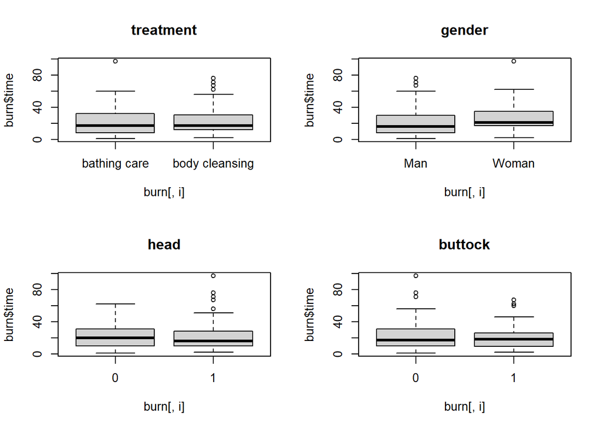

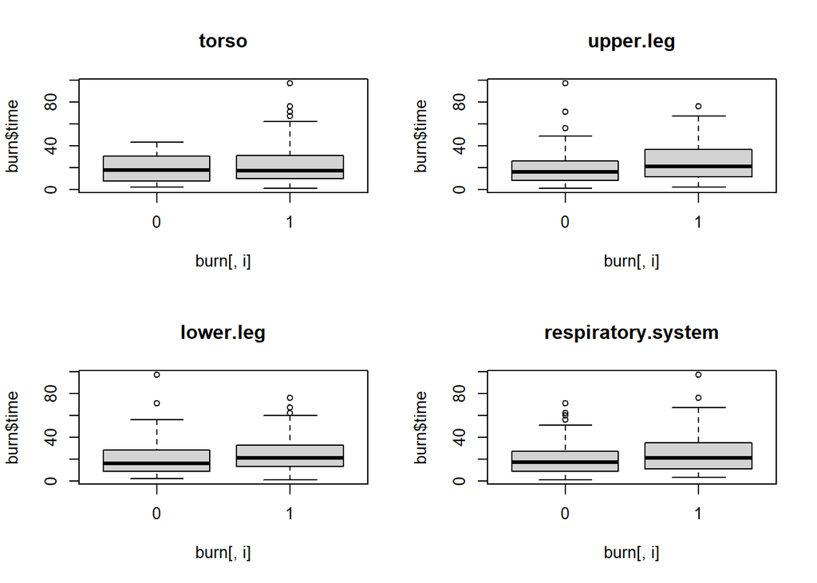

```r
par(mfrow = c(2, 2))
for (i in c(1:2, 4:10)) boxplot(burn$time ~ burn[,
    i], main = names(burn)[i])
```

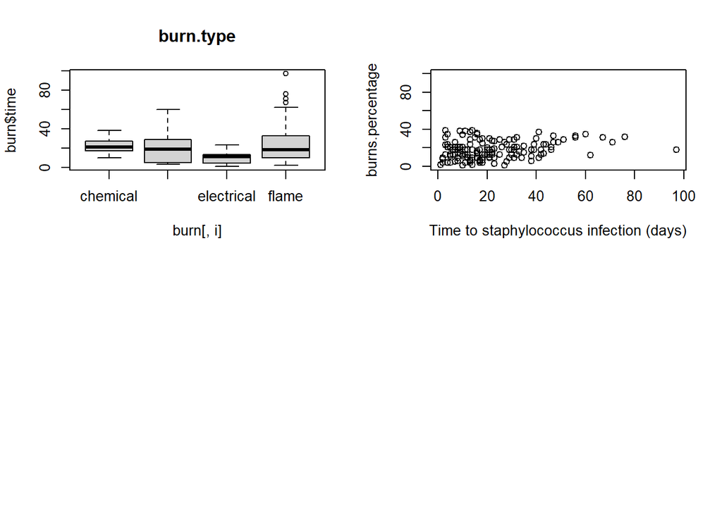

```r
i = 3
plot(burn$time, burn[, i], ylab = names(burn)[i], xlab = "Time to staphylococcus infection (days)",
    ylim = c(0, 100))
```

## 3) Nonparametric analysis

• Estimation of the survival function

```
## Call: survfit(formula = Surv(time, cens) ~ covariata, data = burn)
##
##                           n events median 0.95LCL 0.95UCL
## covariata=bathing care   70     28     47      32      NA
## covariata=body cleansing 84     20     NA      NA      NA
## Call: survfit(formula = Surv(time, cens) ~ covariata, data = burn)
##
##                 covariata=bathing care
##  time n.risk n.event survival std.err lower 95% CI upper 95% CI
##     1     70       1    0.986  0.0142        0.958        1.000
##     3     69       3    0.943  0.0277        0.890        0.999
##     4     66       4    0.886  0.0380        0.814        0.963
##     5     62       1    0.871  0.0400        0.796        0.953
##     6     60       2    0.842  0.0436        0.761        0.932
##     7     58       3    0.799  0.0481        0.710        0.899
```

[output cut: 27 more lines]

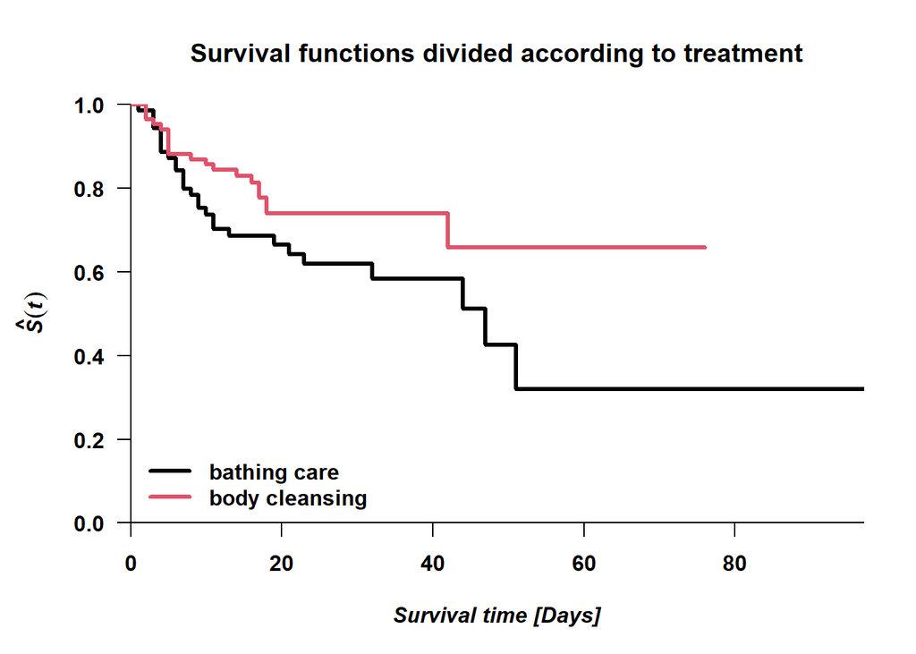

```
## Call: survfit(formula = Surv(time, cens) ~ covariata, data = burn)
##
##                   n events median 0.95LCL 0.95UCL
## covariata=Man   120     40     47      44      NA
## covariata=Woman  34      8     NA      32      NA
## Call: survfit(formula = Surv(time, cens) ~ covariata, data = burn)
##
##                 covariata=Man
##  time n.risk n.event survival std.err lower 95% CI upper 95% CI
##     1    120       1    0.992  0.0083        0.976        1.000
##     2    119       2    0.975  0.0143        0.947        1.000
##     3    117       4    0.942  0.0214        0.901        0.985
##     4    113       5    0.900  0.0274        0.848        0.955
##     5    108       6    0.850  0.0326        0.788        0.916
##     6    101       2    0.833  0.0341        0.769        0.903
```

[output cut: 25 more lines]

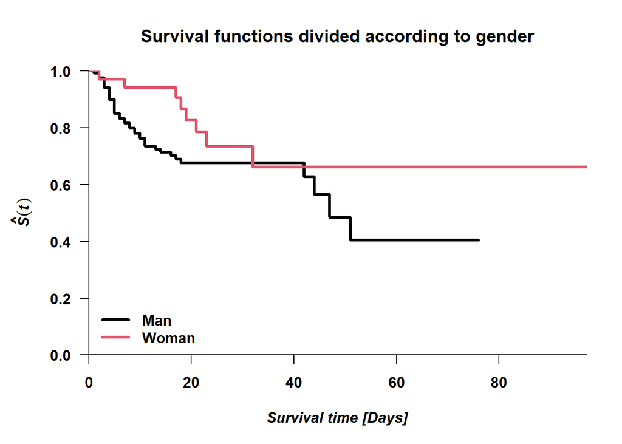

```
## Call: survfit(formula = Surv(time, cens) ~ covariata, data = burn)
##
##              n events median 0.95LCL 0.95UCL
## covariata=0 84     24     NA      42      NA
## covariata=1 70     24     51      44      NA
## Call: survfit(formula = Surv(time, cens) ~ covariata, data = burn)
##
##                 covariata=0
##  time n.risk n.event survival std.err lower 95% CI upper 95% CI
##     1     84       1    0.988  0.0118        0.965        1.000
##     2     83       2    0.964  0.0202        0.925        1.000
##     3     81       2    0.940  0.0258        0.891        0.992
##     4     79       3    0.905  0.0320        0.844        0.970
##     5     76       3    0.869  0.0368        0.800        0.944
##     6     72       2    0.845  0.0395        0.771        0.926
```

[output cut: 30 more lines]

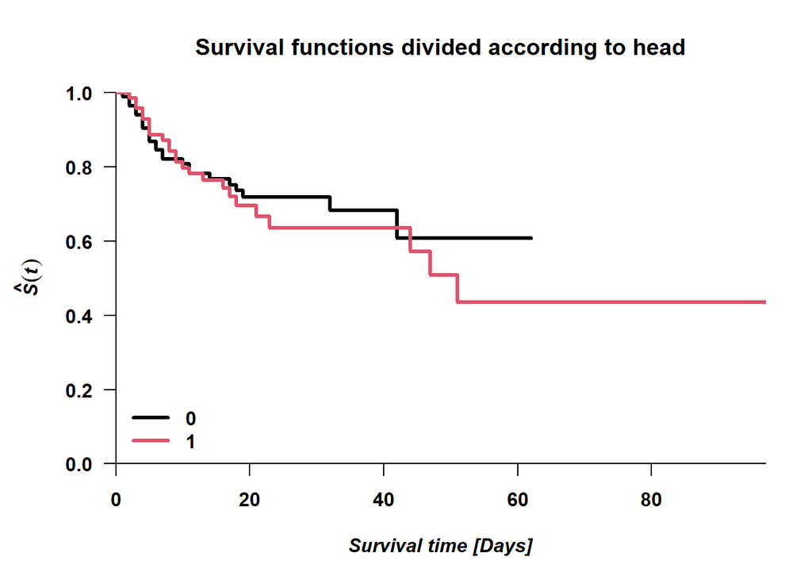

```
## Call: survfit(formula = Surv(time, cens) ~ covariata, data = burn)
##
##               n events median 0.95LCL 0.95UCL
## covariata=0 119     34     51      44      NA
## covariata=1  35     14     NA      18      NA
## Call: survfit(formula = Surv(time, cens) ~ covariata, data = burn)
##
##                 covariata=0
##  time n.risk n.event survival std.err lower 95% CI upper 95% CI
##     1    119       1    0.992 0.00837        0.975        1.000
##     2    118       2    0.975 0.01437        0.947        1.000
##     3    116       3    0.950 0.02006        0.911        0.990
##     4    113       2    0.933 0.02296        0.889        0.979
##     5    111       5    0.891 0.02860        0.836        0.949
##     6    105       2    0.874 0.03046        0.816        0.936
```

[output cut: 29 more lines]

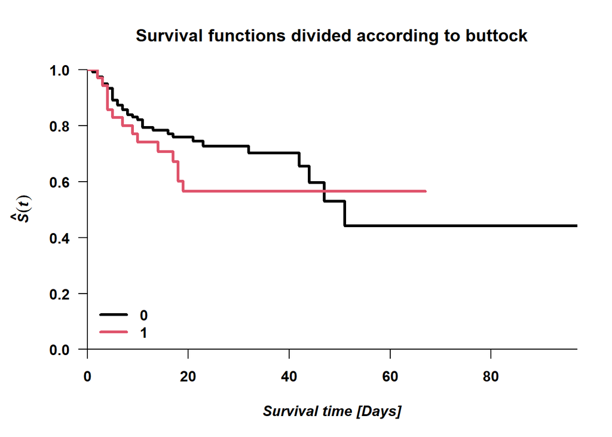

```
## Call: survfit(formula = Surv(time, cens) ~ covariata, data = burn)
##
##               n events median 0.95LCL 0.95UCL
## covariata=0  24      6     NA      NA      NA
## covariata=1 130     42     51      44      NA
## Call: survfit(formula = Surv(time, cens) ~ covariata, data = burn)
##
##                 covariata=0
##  time n.risk n.event survival std.err lower 95% CI upper 95% CI
##     2     24       1    0.958  0.0408        0.882        1.000
##     4     23       1    0.917  0.0564        0.813        1.000
##     6     22       1    0.875  0.0675        0.752        1.000
##     7     21       1    0.833  0.0761        0.697        0.997
##    11     16       1    0.781  0.0873        0.628        0.973
##    19     10       1    0.703  0.1080        0.520        0.950
```

[output cut: 26 more lines]

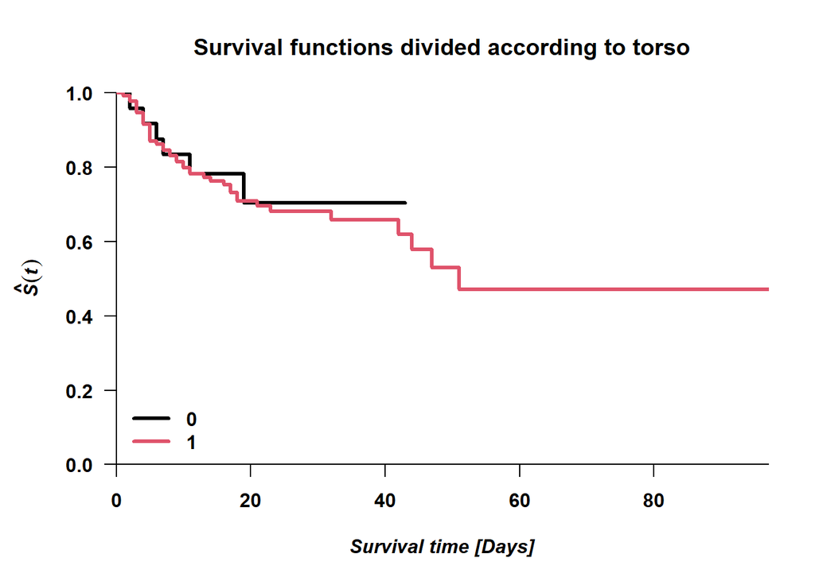

```
## Call: survfit(formula = Surv(time, cens) ~ covariata, data = burn)
##
##              n events median 0.95LCL 0.95UCL
## covariata=0 91     28     44      42      NA
## covariata=1 63     20     NA      51      NA
## Call: survfit(formula = Surv(time, cens) ~ covariata, data = burn)
##
##                 covariata=0
##  time n.risk n.event survival std.err lower 95% CI upper 95% CI
##     1     91       1    0.989  0.0109        0.968        1.000
##     2     90       2    0.967  0.0187        0.931        1.000
##     3     88       3    0.934  0.0260        0.884        0.986
##     4     85       1    0.923  0.0279        0.870        0.979
##     5     84       5    0.868  0.0355        0.801        0.941
##     6     78       2    0.846  0.0379        0.775        0.923
```

[output cut: 29 more lines]

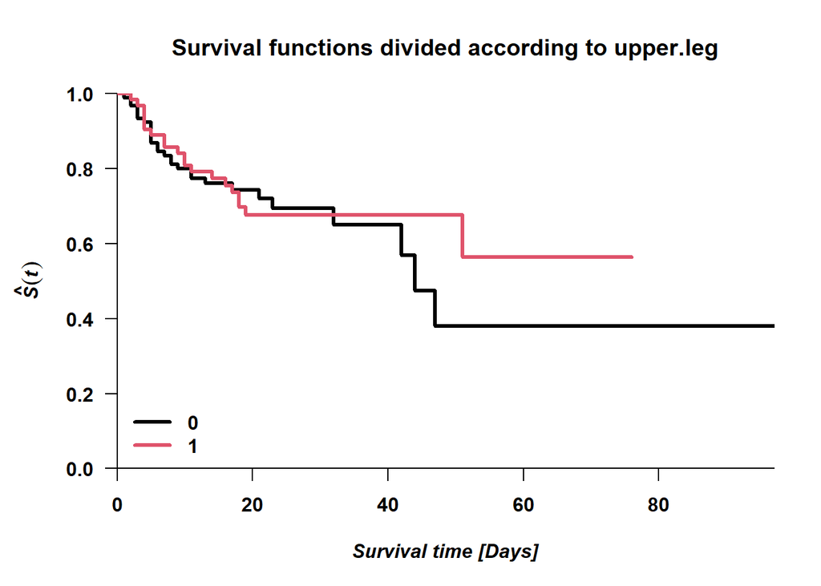

```
## Call: survfit(formula = Surv(time, cens) ~ covariata, data = burn)
##
##               n events median 0.95LCL 0.95UCL
## covariata=0 107     35     47      42      NA
## covariata=1  47     13     NA      NA      NA
## Call: survfit(formula = Surv(time, cens) ~ covariata, data = burn)
##
##                 covariata=0
##  time n.risk n.event survival std.err lower 95% CI upper 95% CI
##     2    107       3    0.972  0.0160        0.941        1.000
##     3    104       2    0.953  0.0204        0.914        0.994
##     4    102       2    0.935  0.0239        0.889        0.983
##     5    100       5    0.888  0.0305        0.830        0.950
##     6     94       2    0.869  0.0327        0.807        0.935
##     7     92       2    0.850  0.0346        0.785        0.921
```

[output cut: 28 more lines]

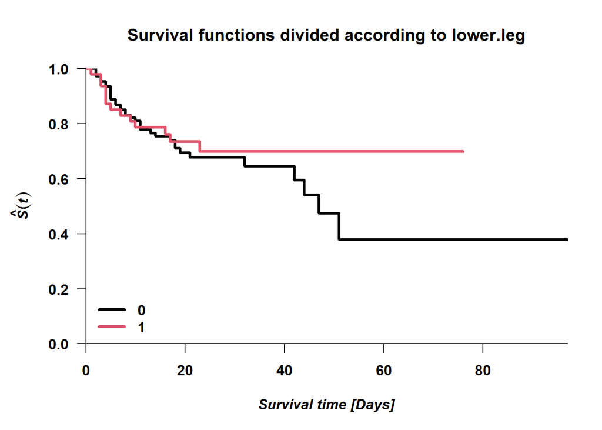

```
## Call: survfit(formula = Surv(time, cens) ~ covariata, data = burn)
##
##               n events median 0.95LCL 0.95UCL
## covariata=0 109     31     NA      51      NA
## covariata=1  45     17     47      32      NA
## Call: survfit(formula = Surv(time, cens) ~ covariata, data = burn)
##
##                 covariata=0
##  time n.risk n.event survival std.err lower 95% CI upper 95% CI
##     1    109       1    0.991 0.00913        0.973        1.000
##     2    108       3    0.963 0.01801        0.929        0.999
##     3    105       2    0.945 0.02185        0.903        0.989
##     4    103       5    0.899 0.02885        0.844        0.957
##     5     98       5    0.853 0.03390        0.789        0.922
##     6     92       2    0.835 0.03561        0.768        0.907
```

[output cut: 26 more lines]

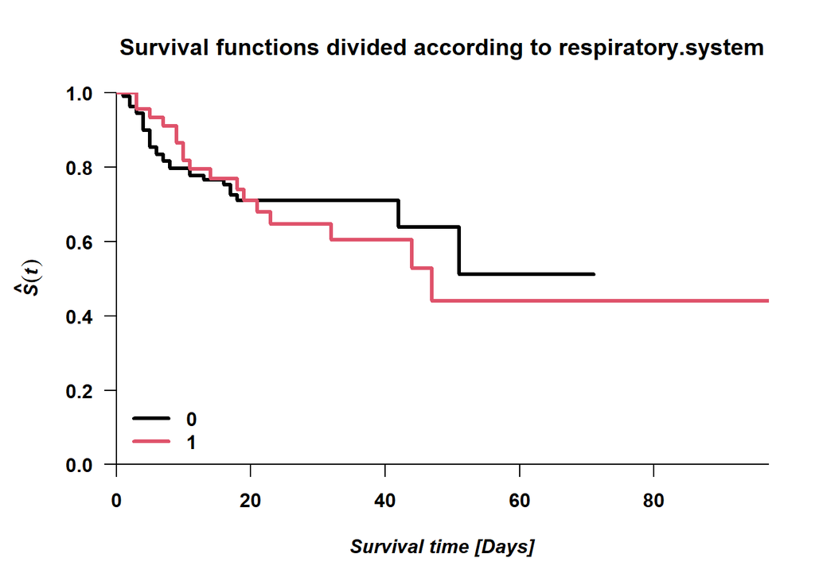

```
## Call: survfit(formula = Surv(time, cens) ~ covariata, data = burn)
##
##                        n events median 0.95LCL 0.95UCL
## covariata=chemical     9      1     NA      NA      NA
## covariata=scalding    18      6     NA       7      NA
## covariata=electrical  11      6     13       5      NA
## covariata=flame      116     35     51      44      NA
## Call: survfit(formula = Surv(time, cens) ~ covariata, data = burn)
##
##                 covariata=chemical
##         time       n.risk      n.event     survival      std.err lower 95% CI
##       18.000        6.000        1.000        0.833        0.152        0.583
## upper 95% CI
##        1.000
##
##                 covariata=scalding
##  time n.risk n.event survival std.err lower 95% CI upper 95% CI
##     3     18       2    0.889  0.0741        0.755        1.000
##     4     16       2    0.778  0.0980        0.608        0.996
##     5     14       1    0.722  0.1056        0.542        0.962
##     7     13       1    0.667  0.1111        0.481        0.924
##
##                 covariata=electrical
##  time n.risk n.event survival std.err lower 95% CI upper 95% CI
##     1     11       1    0.909  0.0867        0.754        1.000
##     2     10       1    0.818  0.1163        0.619        1.000
##     4      9       1    0.727  0.1343        0.506        1.000
##     5      8       2    0.545  0.1501        0.318        0.936
##    13      5       1    0.436  0.1547        0.218        0.874
##
##                 covariata=flame
##  time n.risk n.event survival std.err lower 95% CI upper 95% CI
##     2    116       2    0.983  0.0121        0.959        1.000
##     3    114       2    0.966  0.0169        0.933        0.999
##     4    112       2    0.948  0.0206        0.909        0.989
##     5    110       3    0.922  0.0248        0.875        0.972
##     6    106       2    0.905  0.0272        0.853        0.960
##     7    104       2    0.888  0.0294        0.832        0.947
##     8     99       2    0.870  0.0314        0.810        0.933
##     9     94       2    0.851  0.0333        0.788        0.919
##    10     90       2    0.832  0.0352        0.766        0.904
##    11     86       3    0.803  0.0377        0.733        0.881
##    14     75       1    0.793  0.0387        0.720        0.872
##    16     68       1    0.781  0.0399        0.706        0.863
##    17     63       2    0.756  0.0423        0.678        0.844
##    18     59       1    0.743  0.0435        0.663        0.834
##    19     55       1    0.730  0.0447        0.647        0.823
##    21     51       1    0.715  0.0461        0.631        0.812
##    23     44       1    0.699  0.0478        0.611        0.799
##    32     32       1    0.677  0.0511        0.584        0.785
##    42     18       1    0.640  0.0605        0.531        0.770
##    44     14       1    0.594  0.0714        0.469        0.752
##    47     11       1    0.540  0.0828        0.400        0.729
##    51      8       1    0.473  0.0961        0.317        0.704
```

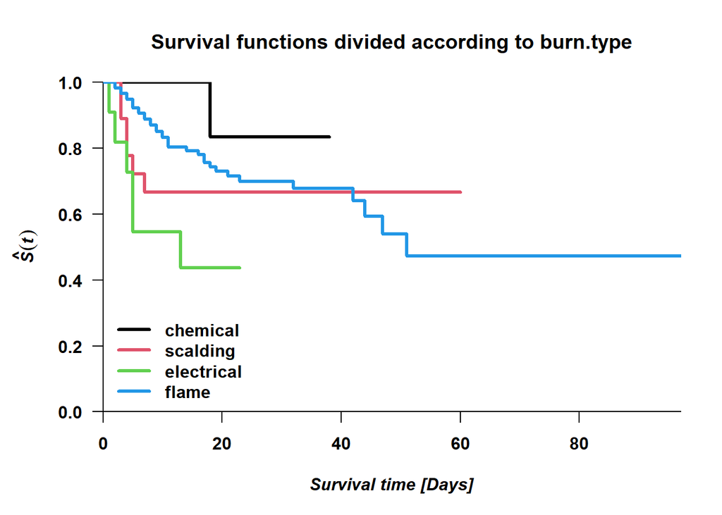

```r
for (indice in c(1:2, 4:10)) {

    covariata = burn[, indice]
    n = length(levels(covariata))
    svf <- survfit(Surv(time, cens) ~ covariata, burn)
    print(svf)
    print(summary(svf))

    par(las = 1, font = 2, font.axis = 2, font.lab = 4,
        bty = "l", mar = c(5, 5, 4, 2))
    plot(svf, col = 1:n, lwd = 3, xlab = "Survival time [Days]",
        ylab = expression(bolditalic(hat(S)(t))), xaxs = "i",
        yaxs = "i", )
    # axis(1, seq(25, 325, 50))
    legend("bottomleft", levels(covariata), lwd = 3,
        col = 1:n, bty = "n")
    title(paste("Survival functions divided according to",
        names(burn)[indice]))

}
```

```r
library(GofCens)
```

```r
# with(subset(burn, treatment == 'treatment 1'),
# cumhazPlot(time, cens, distr = c('weibull',
# 'loglog', 'lognormal'))) with(subset(burn,
# treatment == 'treatment 2'), cumhazPlot(time,
# cens, distr = c('weibull', 'loglog',
# 'lognormal')))
```

• Estimation of the median survival time.

• Fit of a Weibull, log-logistic, or lognormal model.

• Interpretation of the model fit.

• Interpretation of the model parameters in terms of relative hazards or relative odds, and the accelerating factor.

• Fit of the proportional hazards models.

• Interpretation of the model fit.

• Interpretation of the model parameters in terms of relative hazards.

• Analysis of the residuals to check the model’s goodness-of-fit.